# Intro to programming

#### Open-ended comparative plotting

To test how inline autocomplete adapts to instructions.

Creating a distribution check:

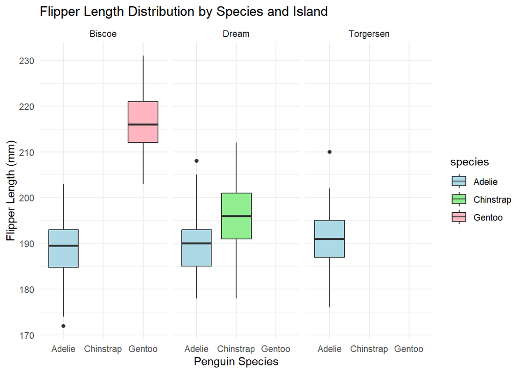

```r
# Create a boxplot using the penguins dataset.
# Compare the flipper_length_mm across the three penguin species.
# Facet the data by island, using custom color palettes.
ggplot(data = penguins) +
  geom_boxplot(mapping = aes(x = species, y = flipper_length_mm, fill = species)) +
  facet_wrap(~ island) +
  scale_fill_manual(values = c("Adelie" = "lightblue", "Chinstrap" = "lightgreen", "Gentoo" = "lightpink")) +
  theme_minimal() +
  labs(x = "Penguin Species", y = "Flipper Length (mm)", title = "Flipper Length Distribution by Species and Island")
```

### Conversational Workspace Engine (chattr)

The chattr package is fully integrated within RStudio, securely reading metadata from the active environment to provide contextual support.

To do this we need to generate an API Key and Securely store it.

Exercise by using this prompt “Show me how to load the built-in iris dataset and use ggplot2 to build a scatter plot of Sepal.Length versus Sepal.Width colored by Species.”

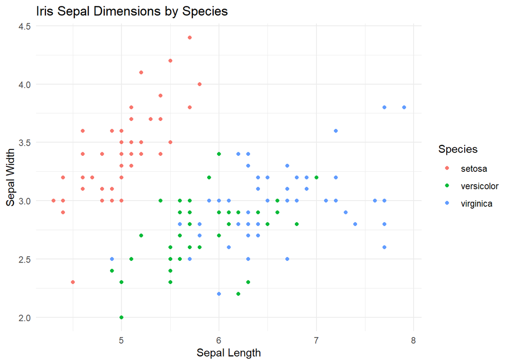

```r
# Using the penguins dataset load the built-in iris dataset
# build a scatterplot for Sepal.Length vs Sepal.Width
# colour the points by Species.
ggplot(data = iris) +
  geom_point(mapping = aes(x = Sepal.Length, y = Sepal.Width, colour = Species)) +
  theme_minimal() +
  labs(x = "Sepal Length", y = "Sepal Width", title = "Iris Sepal Dimensions by Species")
```

### Conditional Logic

This is how we filter outliers, classify categorical variables, or tag environments by environmental stress limits

#### Base R: if-else statements

The classic base R conditional structure screens a single value at a time.

The basic anatomy uses round brackets (), for logical conditions use curly braces {} to enclose the code block that executes when the condition is met.

For example:

```r
# Simple Example: Checking Sea Surface Temperature (SST)
sst <- 30.2

if (sst > 29.5) {
  print("Warning: Marine heatwave threshold exceeded!")
} else {
  print("SST remains within baseline parameters.")
}
```

```
## [1] "Warning: Marine heatwave threshold exceeded!"
```

#### Tidiverse Alternative: Vectorised conditionals (dplyr)

Base R ‘if’ and ‘if-else’ statements are not designed to handle vectorised operations, which are common in data analysis.

#### if_else() function

Allows for efficient vectorised conditional logic.

```r
# Load tidyverse (if not already loaded)
library(tidyverse)

# Sample coral data
coral_monitoring <- tibble(
  site = c("Site_A", "Site_B", "Site_C"),
  depth_m = c(12, 35, 8)
)

# Classify depth using if_else
coral_monitoring <- coral_monitoring %>%
  mutate(zone = if_else(depth_m > 30, "Deep Reef", "Shallow Reef"))
```

Task: finding out what the function mutate(), and the symbol %>% do.

```r
?mutate # adds new variables or transforms existing ones
?`%>%` # pipe operator, allows chaining of commands in a readable way
```

#### case_when() function

Allows for multiple conditions to be evaluated in a single statement. clean sequential evaluation layout using tildes ~

```r
coral_monitoring <- coral_monitoring %>%
  mutate(reef_category = case_when(
    depth_m < 10  ~ "Lagoon / Flats",
    depth_m <= 30 ~ "Crest / Slope",
    depth_m > 30  ~ "Mesophotic / Deep",
    TRUE          ~ "Unclassified" # Catch-all remainder
  ))
```

#### Task: Environmetal stress classification

Write an R script that initialises a tibble

```r
# Create a tibble with sample SST data
# Create a tibble named marine_stations with a salinity column with values [35, 28, 32, and 12]
# Use pipe operator and mutate() combined with case_when() to create a new column named environment_type
# classify values below 15 as "Estuarine", values between 15 and 30 as "Brackish", and values above 30 as "Marine"
marine_stations <- tibble(
  station_id = c("Station_1", "Station_2", "Station_3", "Station_4"),
  salinity = c(35, 28, 32, 12)
)
marine_stations <- marine_stations %>%
  mutate(environment_type = case_when(
    salinity < 15 ~ "Estuarine",
    salinity >= 15 & salinity <= 30 ~ "Brackish",
    salinity > 30 ~ "Marine",
    TRUE ~ "Unclassified"
  ))
marine_stations
```

```
## # A tibble: 4 × 3
##   station_id salinity environment_type
##   <chr>         <dbl> <chr>
## 1 Station_1        35 Marine
## 2 Station_2        28 Brackish
## 3 Station_3        32 Marine
## 4 Station_4        12 Estuarine
```

### Automation - Iterating efficiently

Automation means instructing R to repeat a task across multiple items without manually copy-pasting.

#### Base R: for-loops

This repeats a code chunk for each element in a designated sequence.

Classic loop anatomy:

```r
for (year in 2020:2024) {
  print(paste("Processing climate data for year:", year))
}
```

```
## [1] "Processing climate data for year: 2020"
## [1] "Processing climate data for year: 2021"
## [1] "Processing climate data for year: 2022"
## [1] "Processing climate data for year: 2023"
## [1] "Processing climate data for year: 2024"
```

```r
# Loop across index sequences
transect_lengths <- c(50, 100, 25, 75)

for (i in seq_along(transect_lengths)) {
  print(paste("Transect number", i, "measures", transect_lengths[i], "metres."))
}
```

```
## [1] "Transect number 1 measures 50 metres."
## [1] "Transect number 2 measures 100 metres."
## [1] "Transect number 3 measures 25 metres."
## [1] "Transect number 4 measures 75 metres."
```

### Tidyverse Alternative: Functional Programming (purrr)

For-loops are a core programming construct, they also require the management of index variables (i) and explicitly set up empty ‘containers’ to store results.Resulting in verbose code and hidden bugs.

The purrr package uses map functions, mapping a specific operation onto every item in list or vector, ensuring automatic matches to the output.

Examples of functions and their expected output data type: - map() - Returns a flexible List sturcture - map_dbl() - Returns a vector of decimals/ numeric values - map_chr() - Returns a vector of text strings/characters - map_df() - Returns a combined data frame/ tibble

Example to see the difference between standard for-loop and purrr equivalent.

Using a standard for-loop:

```r
site_areas <- c(144, 400, 625)
results <- numeric(length(site_areas)) # Must build an empty container first

for(i in seq_along(site_areas)) {
  results[i] <- sqrt(site_areas[i]) # Manually manage index and assignment
}
```

The purrr equivalent:

```r
library(purrr)
# Map directly and define your expected output type explicitly
mapped_results <- map_dbl(site_areas, sqrt)
```

#### Iterating across complex groups

combining purrr pipelines inside data frames to split analysis across separate groups:

```r
# Iterate a summary function over split lists of data
iris %>%
  split(.$Species) %>%
  map(~summary(.x))
```

```
## $setosa
##   Sepal.Length    Sepal.Width     Petal.Length    Petal.Width
##  Min.   :4.300   Min.   :2.300   Min.   :1.000   Min.   :0.100
##  1st Qu.:4.800   1st Qu.:3.200   1st Qu.:1.400   1st Qu.:0.200
##  Median :5.000   Median :3.400   Median :1.500   Median :0.200
##  Mean   :5.006   Mean   :3.428   Mean   :1.462   Mean   :0.246
##  3rd Qu.:5.200   3rd Qu.:3.675   3rd Qu.:1.575   3rd Qu.:0.300
##  Max.   :5.800   Max.   :4.400   Max.   :1.900   Max.   :0.600
##        Species
##  setosa    :50
##  versicolor: 0
##  virginica : 0
##
##
##
##
## $versicolor
##   Sepal.Length    Sepal.Width     Petal.Length   Petal.Width          Species
##  Min.   :4.900   Min.   :2.000   Min.   :3.00   Min.   :1.000   setosa    : 0
##  1st Qu.:5.600   1st Qu.:2.525   1st Qu.:4.00   1st Qu.:1.200   versicolor:50
##  Median :5.900   Median :2.800   Median :4.35   Median :1.300   virginica : 0
##  Mean   :5.936   Mean   :2.770   Mean   :4.26   Mean   :1.326
##  3rd Qu.:6.300   3rd Qu.:3.000   3rd Qu.:4.60   3rd Qu.:1.500
##  Max.   :7.000   Max.   :3.400   Max.   :5.10   Max.   :1.800
##
## $virginica
##   Sepal.Length    Sepal.Width     Petal.Length    Petal.Width
##  Min.   :4.900   Min.   :2.200   Min.   :4.500   Min.   :1.400
##  1st Qu.:6.225   1st Qu.:2.800   1st Qu.:5.100   1st Qu.:1.800
##  Median :6.500   Median :3.000   Median :5.550   Median :2.000
##  Mean   :6.588   Mean   :2.974   Mean   :5.552   Mean   :2.026
##  3rd Qu.:6.900   3rd Qu.:3.175   3rd Qu.:5.875   3rd Qu.:2.300
##  Max.   :7.900   Max.   :3.800   Max.   :6.900   Max.   :2.500
##        Species
##  setosa    : 0
##  versicolor: 0
##  virginica :50
##
##
##
```

#### Task using chattr:

Prompt the following into the engine: “I have a list of three vectors containing fish count data. Write a for-loop to calculate the mean of each, and then show me the exact parallel way to do it using purrr’s map_dbl function.”

```r
# Sample data: list of three vectors with fish counts
fish_counts <- list(
  lake1 = c(5, 6, 7, 8),
  lake2 = c(10, 12, 14, 16),
  lake3 = c(2, 3, 5, 7)
)

# For-loop method
means_loop <- numeric(length(fish_counts))
for (i in seq_along(fish_counts)) {
  means_loop[i] <- mean(fish_counts[[i]])
}
means_loop
```

```
## [1]  6.50 13.00  4.25
```

```r
# purrr's map_dbl method
library(purrr)
means_map <- map_dbl(fish_counts, mean)
means_map
```

```
## lake1 lake2 lake3
##  6.50 13.00  4.25
```

### Writing custom functions

Functions package your logic into clear, named, reusable assets.

#### Function construction blueprint

The function consists of a Name, Arguments (input varables), and a Body (execution logic wapped inside curly braces).

Always test functions in a clean local environment, ensuring they rely strictly on the arguments passed directly into them, rather than accidentally grabbing random background objects floating in global R environment.

```r
# Function Definition
calculate_coral_mortality <- function(initial_count, surviving_count) {

  # Logic safety switch using our conditional tools!
  if (initial_count <= 0) {
    stop("Initial count must be greater than zero.")
  }

  mortality_rate <- (initial_count - surviving_count) / initial_count
  return(mortality_rate)
}

# Utilizing your custom function
calculate_coral_mortality(initial_count = 120, surviving_count = 84)
```

```
## [1] 0.3
```

#### Excercise: Custom function construction task.

```r
# Build a custom function named convert_temp_c_to_f
# This function should accept a single argument representing temperature in Celcius.
# The function should perform the math conversion: F = (C * 9/5) + 32
# Include a safety check using an 'if' statement that halts execution via stop() if the entered value is below absolute zero (-273.15°C).
# Test your function with a sample input of 25°C and then with an invalid input of -300°C to see the error handling in action.
convert_temp_c_to_f <- function(temp_c) {
  if (temp_c < -273.15) {
    stop("Temperature cannot be below absolute zero (-273.15°C).")
  }

  temp_f <- (temp_c * 9/5) + 32
  return(temp_f)
}
# Test the function with valid input
convert_temp_c_to_f(25)
```

```
## [1] 77
```

### Advanced scripting extension challenges

Challenge 1: Nested Multi-Vector Iteration

```r
# Given a vector of raw survey counts counts <- c(15, 24, 8, 42) and a vector of species-specific scaling factors factors <- c(1.2, 0.8, 2.5, 1.1)
# Write a mapping statement using map2_dbl()
# The function should iterate through both vectors simultaneously, applying the scaling factor to each corresponding count.
# Do not use a manual index loop
library(purrr)
counts <- c(15, 24, 8, 42)
factors <- c(1.2, 0.8, 2.5, 1.1)
scaled_counts <- map2_dbl(counts, factors, ~ .x
 * .y)
scaled_counts
```

```
## [1] 18.0 19.2 20.0 46.2
```